# Lab 6: Causal Mediation Analysis

Causal Machine Learning

Stijn Vansteelandt and Federico Bertoia, Ghent University

2026-03-31

## 0. Introduction

The goal of this lab is to estimate **Natural Direct and Indirect Effects (NDE/NIE)** using the JOBS II randomized experiment. Mediation analysis decomposes the total causal effect of a treatment $A$ on an outcome $Y$ into:

- A **Natural Direct Effect (NDE)**: the effect of $A$ on $Y$ that does not operate through the mediator $M$,
- A **Natural Indirect Effect (NIE)**: the effect of $A$ on $Y$ that is mediated through $M$.

Formally, under the potential outcomes framework:

$$\text{NDE} = E[Y^{1, M^0} - Y^{0, M^0}],$$

$$\text{NIE} = E[Y^{1, M^1} - Y^{1, M^0}],$$

where $Y^{a, m}$ denotes the potential outcome under treatment $A = a$ and mediator value $M = m$, and $M^a$ is the potential mediator value under treatment $A = a$.

The **total effect** decomposes additively:

$$\text{ATE} = \text{NDE} + \text{NIE}.$$

Identification of the NDE and NIE requires the standard causal assumptions (consistency, positivity, and conditional exchangeability), plus the **cross-world independence** assumption: $Y^{a,m} \perp M^{a'} \mid W$ for all $a, a', m$.

We use the `medoutcon` package, which implements a nonparametric one-step estimator that is doubly robust and asymptotically efficient, combined with Super Learner via `sl3` for flexible nuisance estimation.

### Data

The **JOBS II** dataset comes from a randomized field experiment evaluating a job training intervention for unemployed workers. The treatment $A$ (`treat`) indicates whether participants were randomly assigned to the job search intervention. Two outcomes and two mediators are considered across the exercises below.

| Variable | Role | Description |
| --- | --- | --- |
| `treat` | Treatment | Assignment to job training (binary) |
| `job_seek` | Mediator | Job search self-efficacy score (continuous) |
| `work1` | Mediator / Outcome | Employment status at follow-up (binary) |
| `depress2` | Outcome | Depressive symptoms at follow-up (continuous) |
| `econ_hard`, `depress1`, `sex`, `age`, `occp`, `marital`, `nonwhite`, `educ`, `income` | Confounders $W$ | Baseline covariates |

```r
# ── Packages ──────────────────────────────────────────────────────────────────
library(mediation)   # install.packages("mediation")
library(sl3)         # remotes::install_github("tlverse/sl3")
library(medoutcon)   # remotes::install_github("nhejazi/medoutcon")
library(dplyr)

# ── Reproducibility ───────────────────────────────────────────────────────────
set.seed(123)

# ── Load data ─────────────────────────────────────────────────────────────────
data(jobs)
jobs <- as.data.frame(jobs)

# ── Initial inspection ────────────────────────────────────────────────────────
glimpse(jobs)
```

```
## Rows: 899
## Columns: 17
## $ treat     <int> 1, 1, 1, 0, 1, 1, 0, 0, 0, 1, 1, 1, 1, 1, 1, 1, 1, 1, 0, 0, …
## $ econ_hard <dbl> 3.00, 3.67, 4.00, 2.33, 1.33, 3.00, 3.33, 4.00, 1.33, 3.00, …
## $ depress1  <dbl> 1.91, 1.36, 2.09, 1.45, 1.73, 1.55, 2.45, 2.73, 1.27, 1.64, …
## $ sex       <int> 1, 0, 1, 0, 1, 0, 1, 1, 1, 0, 0, 1, 1, 0, 1, 0, 1, 1, 1, 1, …
## $ age       <dbl> 34.16712, 26.10137, 35.02192, 27.48767, 31.61096, 40.43835, …
## $ occp      <fct> professionals, operatives/kindred wrks, operatives/kindred w…
## $ marital   <fct> married, nevmarr, nevmarr, married, separtd, married, marrie…
## $ nonwhite  <fct> non.white1, white0, non.white1, white0, non.white1, white0, …
## $ educ      <fct> gradwk, somcol, somcol, bach, highsc, highsc, gradwk, somcol…
## $ income    <fct> 50k+, 15t24k, 25t39k, 25t39k, 25t39k, 50k+, 50k+, 15t24k, 15…
## $ job_seek  <dbl> 4.833333, 3.833333, 4.500000, 3.666667, 2.500000, 4.000000, …
## $ depress2  <dbl> 1.727273, 2.000000, 2.181818, 1.545455, 2.363636, 1.181818, …
## $ work1     <fct> psyemp, psyemp, psyump, psyump, psyump, psyump, psyump, psyu…
## $ comply    <int> 0, 0, 0, 0, 1, 1, 0, 0, 0, 0, 1, 0, 0, 1, 0, 0, 1, 0, 0, 0, …
## $ control   <fct> treat, treat, treat, control, treat, treat, control, control…
## $ job_dich  <dbl> 1, 0, 1, 0, 0, 1, 1, 1, 0, 0, 1, 1, 0, 0, 1, 1, 1, 1, 1, 0, …
## $ job_disc  <dbl> 4, 3, 4, 3, 2, 3, 3, 3, 3, 2, 4, 3, 1, 3, 3, 3, 3, 3, 4, 2, …
```

> **Note:** Run `?jobs` in your console to view full variable documentation for the JOBS II dataset.

## 1. Exploratory Data Analysis

Before estimating mediation effects, we briefly explore the key variables: treatment assignment, the mediator `job_seek`, and the two outcomes `work1` and `depress2`.

### 1.1 Treatment and mediator distribution

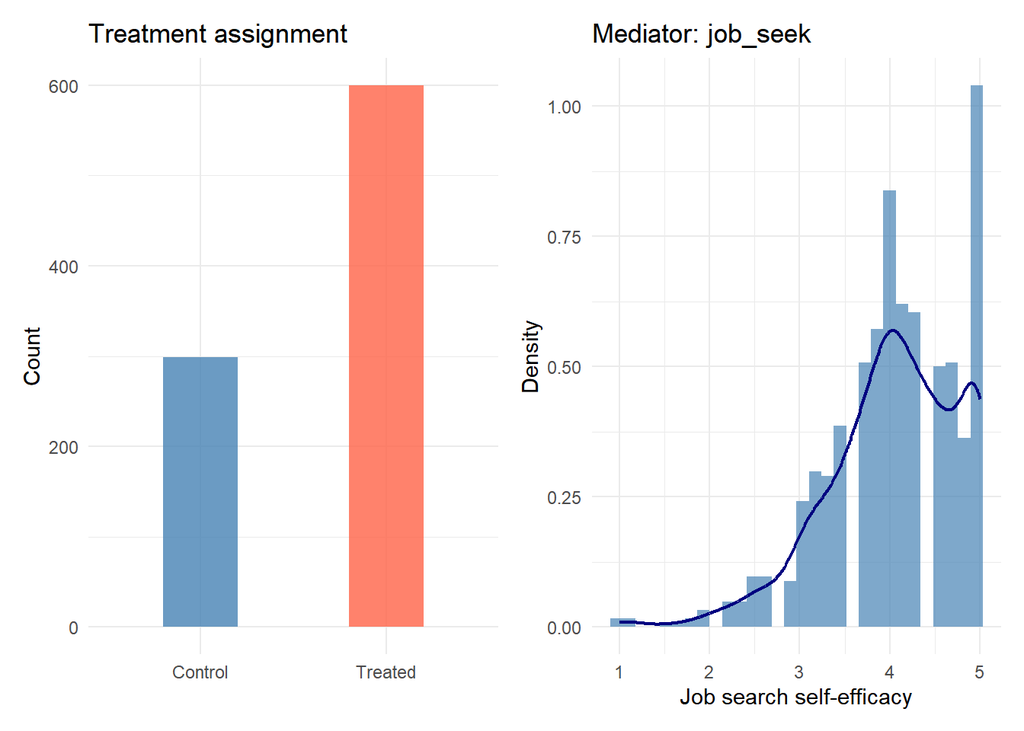

```r
library(ggplot2)
library(patchwork)

p1 <- jobs %>%
  mutate(treat = factor(treat, labels = c("Control", "Treated"))) %>%
  ggplot(aes(x = treat, fill = treat)) +
  geom_bar(alpha = 0.8, width = 0.4) +
  scale_fill_manual(values = c("steelblue", "tomato")) +
  theme_minimal() +
  labs(x = NULL, y = "Count", title = "Treatment assignment") +
  theme(legend.position = "none")

p2 <- ggplot(jobs, aes(x = job_seek)) +
  geom_histogram(aes(y = after_stat(density)), bins = 30,
                 fill = "steelblue", alpha = 0.7) +
  geom_density(color = "navy", linewidth = 0.8) +
  theme_minimal() +
  labs(x = "Job search self-efficacy", y = "Density",
       title = "Mediator: job_seek")

p1 + p2
```

### 1.2 Mediator by treatment group

Does the training intervention increase job search self-efficacy? We compare the distribution of `job_seek` across treatment arms.

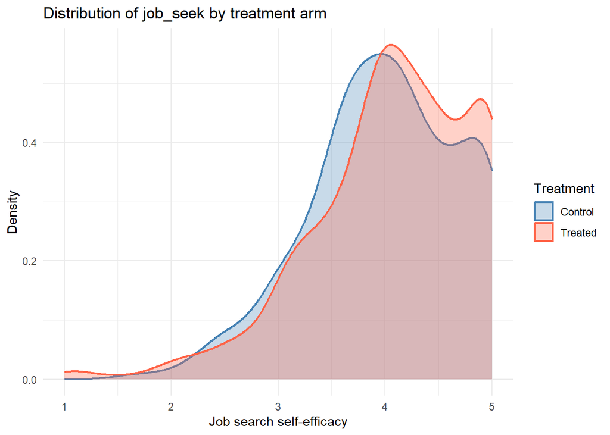

```r
jobs %>%
  mutate(treat = factor(treat, labels = c("Control", "Treated"))) %>%
  ggplot(aes(x = job_seek, fill = treat, color = treat)) +
  geom_density(alpha = 0.3, linewidth = 0.8) +
  scale_fill_manual(values = c("steelblue", "tomato")) +
  scale_color_manual(values = c("steelblue", "tomato")) +
  theme_minimal() +
  labs(x = "Job search self-efficacy", y = "Density",
       fill = "Treatment", color = "Treatment",
       title = "Distribution of job_seek by treatment arm")
```

### 1.3 Outcome distributions

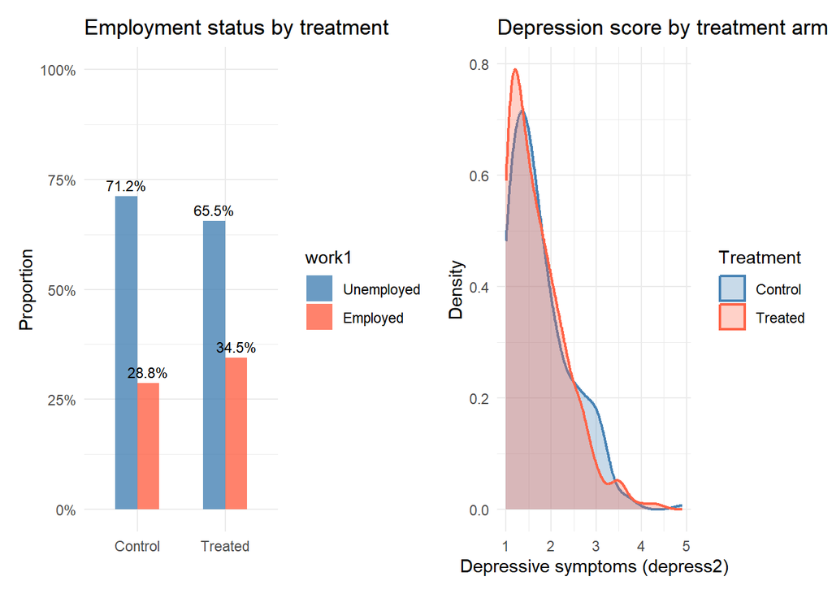

```r
p3 <- jobs %>%
  mutate(
    work1 = factor(as.numeric(work1) - 1, labels = c("Unemployed", "Employed")),
    treat = factor(treat, labels = c("Control", "Treated"))
  ) %>%
  count(treat, work1) %>%
  group_by(treat) %>%
  mutate(prop = n / sum(n)) %>%
  ggplot(aes(x = treat, y = prop, fill = work1)) +
  geom_col(position = "dodge", alpha = 0.8, width = 0.5) +
  geom_text(aes(label = scales::percent(prop, accuracy = 0.1)),
            position = position_dodge(width = 0.5), vjust = -0.5, size = 3) +
  scale_fill_manual(values = c("steelblue", "tomato")) +
  scale_y_continuous(labels = scales::percent, limits = c(0, 1)) +
  theme_minimal() +
  labs(x = NULL, y = "Proportion", fill = "work1",
       title = "Employment status by treatment")

p4 <- jobs %>%
  mutate(treat = factor(treat, labels = c("Control", "Treated"))) %>%
  ggplot(aes(x = depress2, fill = treat, color = treat)) +
  geom_density(alpha = 0.3, linewidth = 0.8) +
  scale_fill_manual(values = c("steelblue", "tomato")) +
  scale_color_manual(values = c("steelblue", "tomato")) +
  theme_minimal() +
  labs(x = "Depressive symptoms (depress2)", y = "Density",
       fill = "Treatment", color = "Treatment",
       title = "Depression score by treatment arm")

p3 + p4
```

## 2. Super Learner Setup

We use `sl3` to build a Super Learner for nuisance function estimation. The `medoutcon` package requires three nuisance components:

- $g(A \mid W)$: the propensity score (treatment model),
- $h(A \mid M, W)$: a secondary propensity model conditioning on the mediator,
- $b(Y \mid A, M, W)$: the outcome regression.

We construct two stacks: one for **binary** outputs (used for $g$ and $h$) and one for **continuous** outputs (used for $b$ when $Y$ is continuous).

### 2.1 Binary Super Learner

```r
sl3_list_learners("binomial")
```

```
##  [1] "Lrnr_bartMachine"               "Lrnr_bayesglm"
##  [3] "Lrnr_bound"                     "Lrnr_caret"
##  [5] "Lrnr_cv_selector"               "Lrnr_dbarts"
##  [7] "Lrnr_earth"                     "Lrnr_ga"
##  [9] "Lrnr_gam"                       "Lrnr_gbm"
## [11] "Lrnr_glm"                       "Lrnr_glm_fast"
## [13] "Lrnr_glm_semiparametric"        "Lrnr_glmnet"
## [15] "Lrnr_glmtree"                   "Lrnr_grf"
## [17] "Lrnr_grfcate"                   "Lrnr_gru_keras"
## [19] "Lrnr_h2o_glm"                   "Lrnr_h2o_grid"
## [21] "Lrnr_hal9001"                   "Lrnr_lightgbm"
## [23] "Lrnr_lstm_keras"                "Lrnr_mean"
## [25] "Lrnr_nnet"                      "Lrnr_nnls"
## [27] "Lrnr_optim"                     "Lrnr_pkg_SuperLearner"
## [29] "Lrnr_pkg_SuperLearner_method"   "Lrnr_pkg_SuperLearner_screener"
## [31] "Lrnr_polspline"                 "Lrnr_randomForest"
## [33] "Lrnr_ranger"                    "Lrnr_rpart"
## [35] "Lrnr_screener_correlation"      "Lrnr_solnp"
## [37] "Lrnr_stratified"                "Lrnr_svm"
## [39] "Lrnr_xgboost"
```

```r
lrn_glm_bin <- Lrnr_glm_fast$new(family = binomial())
lrn_gam_bin <- Lrnr_gam$new(family = binomial())
lrn_earth_bin <- Lrnr_earth$new(degree = 2)
lrn_ranger_bin <- Lrnr_ranger$new(probability = TRUE)

# Stack and combine into Super Learner
stack_bin <- Stack$new(lrn_glm_bin, lrn_gam_bin, lrn_earth_bin, lrn_ranger_bin)
sl_bin    <- Lrnr_sl$new(learners = stack_bin)
```

### 2.2 Continuous Super Learner

```r
sl3_list_learners("continuous")
```

```
##  [1] "Lrnr_arima"                     "Lrnr_bartMachine"
##  [3] "Lrnr_bayesglm"                  "Lrnr_bound"
##  [5] "Lrnr_caret"                     "Lrnr_cv_selector"
##  [7] "Lrnr_dbarts"                    "Lrnr_earth"
##  [9] "Lrnr_expSmooth"                 "Lrnr_ga"
## [11] "Lrnr_gam"                       "Lrnr_gbm"
## [13] "Lrnr_glm"                       "Lrnr_glm_fast"
## [15] "Lrnr_glm_semiparametric"        "Lrnr_glmnet"
## [17] "Lrnr_glmtree"                   "Lrnr_grf"
## [19] "Lrnr_grfcate"                   "Lrnr_gru_keras"
## [21] "Lrnr_gts"                       "Lrnr_h2o_glm"
## [23] "Lrnr_h2o_grid"                  "Lrnr_hal9001"
## [25] "Lrnr_HarmonicReg"               "Lrnr_hts"
## [27] "Lrnr_lightgbm"                  "Lrnr_lstm_keras"
## [29] "Lrnr_mean"                      "Lrnr_multiple_ts"
## [31] "Lrnr_nnet"                      "Lrnr_nnls"
## [33] "Lrnr_optim"                     "Lrnr_pkg_SuperLearner"
## [35] "Lrnr_pkg_SuperLearner_method"   "Lrnr_pkg_SuperLearner_screener"
## [37] "Lrnr_polspline"                 "Lrnr_randomForest"
## [39] "Lrnr_ranger"                    "Lrnr_rpart"
## [41] "Lrnr_rugarch"                   "Lrnr_screener_correlation"
## [43] "Lrnr_solnp"                     "Lrnr_stratified"
## [45] "Lrnr_svm"                       "Lrnr_tsDyn"
## [47] "Lrnr_xgboost"
```

```r
lrn_glm_cont <- Lrnr_glm_fast$new(family = gaussian())
lrn_gam_cont <- Lrnr_gam$new(family = gaussian())
lrn_earth_cont <- Lrnr_earth$new(degree = 2)
lrn_ranger_cont <- Lrnr_ranger$new(probability = FALSE)

# Stack and combine into Super Learner
stack_cont <- Stack$new(lrn_glm_cont, lrn_gam_cont, lrn_earth_cont, lrn_ranger_cont)
sl_cont    <- Lrnr_sl$new(learners = stack_cont)
```

## 3. Question 1 — DAG

```r
library(DiagrammeR)

# ── Question 1: Full DAG (X, M, Z, Y, C) ─────────────────────────────────────
dag_q1 <- grViz("
digraph Q1 {
  graph [layout = neato, bgcolor = transparent]

  node [shape = plaintext, fontname = 'Helvetica', fontsize = 16]

  X [pos = '0,0!']
  M [pos = '2,1.5!']
  Z [pos = '4,1.5!']
  Y [pos = '6,0!']
  C [pos = '3,-1.5!']

  edge [arrowhead = vee, arrowsize = 0.7, penwidth = 1.5, color = '#444444']
  X -> M
  X -> Z
  X -> Y
  M -> Z
  M -> Y
  Z -> Y

  edge [arrowhead = vee, arrowsize = 0.7, penwidth = 1.2,
        style = dashed, color = '#888888']
  C -> M
  C -> Z
  C -> Y
}
")
dag_q1
```

[interactive chart not shown]

where

- $Y=$ depressive symptoms (outcome),
- $X=$ job training intervention (exposure),
- $M=$ job search self-efficacy (mediator),
- $Z=$ employment status (mediator/outcome) and
- $C=$ baseline covariates.

### 3.1 Identification Assumptions for Causal Mediation Analysis

Identification of the NDE and NIE via the mediation formula requires four untestable assumptions. Below we state each one precisely and interpret it in the JOBS II context.

**Assumption 1 — No unmeasured exposure–outcome confounding:**
$$Y^{1,m}
\perp\!\!\!\perp X \mid C$$
The potential outcome $Y^{1,m}$ must be independent of treatment assignment, conditional on the baseline covariates $C$. In other words, there should be no common causes of the job training intervention $X$ and depressive symptoms $Y$ that are not captured by $C$.

**Assumption 2 — No unmeasured exposure–mediator confounding:**
$$M^0 \perp\!\!\!\perp
X \mid C$$
The potential mediator value under control, $M^0$, must be independent of treatment assignment given $C$. There should be no unmeasured common causes of the intervention $X$ and job search self-efficacy $M$.

**Assumption 3 — No unmeasured mediator–outcome confounding:**
$$Y^{1,m}
\perp\!\!\!\perp M \mid X = 1, C$$
Even after conditioning on treatment and baseline covariates, there should be no unmeasured variables that simultaneously affect the mediator $M$ and the outcome $Y$. Crucially, this assumption is required **even in randomized experiments**, since the mediator is never randomized.

**Assumption 4 — No exposure-induced mediator–outcome confounding (cross-world assumption):**
$$Y^{1,m} \perp\!\!\!\perp M^0 \mid C$$
This is the so-called *cross-world* assumption: the potential outcome under treatment ($Y^{1,m}$) must be independent of the potential mediator under control ($M^0$), given baseline covariates $C$. It rules out the existence of any post-treatment variable $L$ that is (i) caused by $X$ and (ii) a confounder of the $M$–$Y$ relationship.

> **Remark:** Assumptions 1 and 2 hold by design in JOBS II, since treatment $X$ is randomly assigned. Assumptions 3 and 4 are not guaranteed and must be justified.

## 4. Question 2 — NDE and NIE: Effect of Training on Employment

We estimate the NDE and NIE of the job training intervention ($A$) on **employment status**, $Y =$ `work1`, (binary), mediated through **job search self-efficacy**, $M =$ `job_seek` (continuous).

The mediation model is:

```r
dag_q2 <- grViz("
digraph Q2 {
  graph [layout = neato, bgcolor = transparent]

  node [shape = plaintext, fontname = 'Helvetica', fontsize = 16]

  X [pos = '0,0!']
  M [pos = '2,1.5!']
  Z [pos = '4,0!']
  C [pos = '2,-1.5!']

  edge [arrowhead = vee, arrowsize = 0.7, penwidth = 1.5, color = '#444444']
  X -> M
  X -> Z
  M -> Z

  edge [arrowhead = vee, arrowsize = 0.7, penwidth = 1.2,
        style = dashed, color = '#888888']
  C -> M
  C -> Z
}
")
dag_q2
```

[interactive chart not shown]

where

- $X=$ job training intervention (exposure),
- $M=$ job search self-efficacy (mediator),
- $Z=$ employment status (mediator/outcome) and
- $C=$ baseline covariates.

```r
W <- jobs[, c("econ_hard", "depress1", "sex", "age", "occp",
              "marital", "nonwhite", "educ", "income")]
A <- jobs$treat
Z <- NULL
Y <- as.numeric(jobs$work1) - 1
M <- jobs$job_seek

folds <- 5
```

### 4.1 Natural Direct Effect

```r
nde1 <- medoutcon(
  W = W, A = A, Z = NULL, M = M, Y = Y,
  g_learners = sl_bin,
  h_learners = sl_bin,
  b_learners = sl_bin,
  effect     = "direct",
  estimator  = "onestep",
  estimator_args = list(cv_folds = folds)
)

nde1
```

### 4.2 Natural Indirect Effect

```r
nie1 <- medoutcon(
  W = W, A = A, Z = NULL, M = M, Y = Y,
  g_learners = sl_bin,
  h_learners = sl_bin,
  b_learners = sl_bin,
  effect     = "indirect",
  estimator  = "onestep",
  estimator_args = list(cv_folds = folds)
)

nie1
```

> **Interpretation:** The NDE captures how much of the treatment effect on employment operates through pathways other than job search self-efficacy. The NIE quantifies what fraction flows through the mediator $M$.

### 4.3 Plausibility of the Identification Assumptions

We now evaluate each of the four assumptions in the context of Question 2, where $X =$ `treat`, $M =$ `job_seek`, $Y =$ `work1`, and $C$ includes the nine baseline covariates.

**Assumption 1 (No exposure–outcome confounding):** This assumption holds by design. Because workers were randomly assigned to treatment or control, the intervention $X$ is independent of all pre-treatment variables, including any unmeasured ones. There is no need to rely on $C$ to block confounding of the $X$–$Y$ relationship, though adjusting for $C$ can improve precision.

**Assumption 2 (No exposure–mediator confounding):** This assumption also holds by design for the same reason. Random assignment ensures that $X$ is independent of all baseline characteristics, ruling out common causes of treatment and job search self-efficacy. No unmeasured confounding of the $X$–$M$ path is possible by construction.

**Assumption 3 (No mediator–outcome confounding):** This assumption is *not* guaranteed by randomization. It requires that, among treated participants and conditional on $C$, there are no unmeasured variables jointly influencing job search self-efficacy and subsequent employment. A plausible violation would be **self-confidence or general motivation**: a highly motivated individual may naturally report higher self-efficacy *and* be more likely to find work regardless of the training content. Unless motivation is captured in $C$, Assumption 3 fails.

**Assumption 4 (Cross-world / no exposure-induced M–Y confounding):** This assumption requires that no post-treatment variable $L$, caused by the training workshop $X$, simultaneously confounds the $M$–$Y$ relationship. A concrete threat is **social support networks** formed during the workshops: participation could build peer connections that both boost self-efficacy ($M$) and improve job search success ($Y$) through a channel unrelated to the training content itself. Since such networks are created *by* the intervention and confound $M$ and $Y$, Assumption 4 is violated.

## 5. Question 3 — NDE and NIE: Effect of Training on Depression with Two Mediators

We now turn to a **continuous outcome**, $Y =$ `depress2` (depressive symptoms), and consider **two mediators jointly**: job search self-efficacy , $M_1 =$ `job_seek`, and employment status, $M_2 =$ `work1`.

When $M = (M_1, M_2)$, the NIE captures the total indirect effect through both mediators simultaneously.

```r
dag_q3 <- grViz("
digraph NIE_Q3 {
  graph [layout = neato, bgcolor = transparent]
  node [shape = plaintext, fontname = 'Helvetica', fontsize = 16]

  X [pos = '0,0!']
  M [pos = '2,1.5!']
  Z [pos = '4,1.5!']
  Y [pos = '6,0!']
  C [pos = '3,-1.5!']

  edge [arrowhead = vee, arrowsize = 0.7, penwidth = 2.0, color = 'red']
  X -> M
  X -> Z
  M -> Y
  Z -> Y

  edge [arrowhead = vee, arrowsize = 0.7, penwidth = 1.5, color = '#444444']
  X -> Y

  edge [arrowhead = vee, arrowsize = 0.7, penwidth = 2.0, style = dashed, color = 'blue']
  M -> Z

  edge [arrowhead = vee, arrowsize = 0.7, penwidth = 1.2,
        style = dashed, color = '#888888']
  C -> M
  C -> Z
  C -> Y
}
")
dag_q3
```

[interactive chart not shown]

```r
Y  <- jobs$depress2
M1 <- jobs$job_seek
M2 <- as.numeric(jobs$work1) - 1
```

### 5.1 Natural Direct Effect (two mediators)

```r
nde2 <- medoutcon(
  W = W, A = A, Z = NULL,
  M = cbind(M1, M2),
  Y = Y,
  g_learners = sl_bin,
  h_learners = sl_bin,
  b_learners = sl_cont,
  effect     = "direct",
  estimator  = "onestep",
  estimator_args = list(cv_folds = folds)
)

nde2
```

### 5.2 Natural Indirect Effect (two mediators)

```r
nie2 <- medoutcon(
  W = W, A = A, Z = NULL,
  M = cbind(M1, M2),
  Y = Y,
  g_learners = sl_bin,
  h_learners = sl_bin,
  b_learners = sl_cont,
  effect     = "indirect",
  estimator  = "onestep",
  estimator_args = list(cv_folds = folds)
)

nie2
```

> **Interpretation:** With both mediators included, the NIE measures the combined indirect effect of the intervention on depression transmitted through changes in job search self-efficacy *and* employment status. The NDE captures what remains after blocking both pathways.

## 6. Questions 4 & 5 — Path-Specific Effect via Mediator Difference

We now isolate the **path-specific indirect effect** that flows exclusively through employment status $M_2$, not through job search self-efficacy $M_1$. This path-specific NIE can be recovered as:

$$\text{NIE}_{M_2} = \text{NIE}_{(M_1, M_2)} - \text{NIE}_{M_1},$$

where $\text{NIE}_{M_1}$ is the NIE with only $M_1$ as mediator, and $\text{NIE}_{(M_1, M_2)}$ was estimated in the previous section.

**NIE from Question 3** — indirect effect through **both** $M$ and $Z$ jointly.

```r
library(DiagrammeR)

dag_q3 <- grViz("
digraph NIE_Q3 {
  graph [layout = neato, bgcolor = transparent]
  node [shape = plaintext, fontname = 'Helvetica', fontsize = 16]

  X [pos = '0,0!']
  M [pos = '2,1.5!']
  Z [pos = '4,1.5!']
  Y [pos = '6,0!']
  C [pos = '3,-1.5!']

  edge [arrowhead = vee, arrowsize = 0.7, penwidth = 2.0, color = 'red']
  X -> M
  X -> Z
  M -> Y
  Z -> Y

  edge [arrowhead = vee, arrowsize = 0.7, penwidth = 1.5, color = '#444444']
  X -> Y

  edge [arrowhead = vee, arrowsize = 0.7, penwidth = 2.0, style = dashed, color = 'blue']
  M -> Z

  edge [arrowhead = vee, arrowsize = 0.7, penwidth = 1.2,
        style = dashed, color = '#888888']
  C -> M
  C -> Z
  C -> Y
}
")
dag_q3
```

[interactive chart not shown]

where

- $Y=$ depressive symptoms (outcome),
- $X=$ job training intervention (exposure),
- $M=$ job search self-efficacy (mediator),
- $Z=$ employment status (mediator/outcome) and
- $C=$ baseline covariates.

**NIE from Question 4(a)** — indirect effect through $M$ only.

```r
dag_q4 <- grViz("
digraph NIE_Q4a {
  graph [layout = neato, bgcolor = transparent]
  node [shape = plaintext, fontname = 'Helvetica', fontsize = 16]

  X [pos = '0,0!']
  M [pos = '2,1.5!']
  Z [pos = '4,1.5!']
  Y [pos = '6,0!']
  C [pos = '3,-1.5!']

  edge [arrowhead = vee, arrowsize = 0.7, penwidth = 2.0, color = 'red']
  X -> M
  M -> Y

  edge [arrowhead = vee, arrowsize = 0.7, penwidth = 1.5, color = '#444444']
  X -> Z
  X -> Y
  Z -> Y

  edge [arrowhead = vee, arrowsize = 0.7, penwidth = 2.0, style = dashed, color = 'blue']
  M -> Z

  edge [arrowhead = vee, arrowsize = 0.7, penwidth = 1.2,
        style = dashed, color = '#888888']
  C -> M
  C -> Z
  C -> Y
}
")
dag_q4
```

[interactive chart not shown]

where

- $Y=$ depressive symptoms (outcome),
- $X=$ job training intervention (exposure),
- $M=$ job search self-efficacy (mediator),
- $Z=$ employment status (mediator/outcome) and
- $C=$ baseline covariates.

### 6.1 NIE through $M_1$ only (job search self-efficacy)

```r
nie_MY <- medoutcon(
  W = W, A = A, Z = NULL,
  M = M1,
  Y = Y,
  g_learners = sl_bin,
  h_learners = sl_bin,
  b_learners = sl_cont,
  effect     = "indirect",
  estimator  = "onestep",
  estimator_args = list(cv_folds = folds)
)

nie_MY
```

### 6.2 Path-specific NIE through $M_2$ (employment status)

**The difference** $\text{NIE}_{(M,Z)} - \text{NIE}_{M}$ therefore isolates the path $X \to Z \to Y$ — the part of the indirect effect that flows through employment status **directly**, bypassing job search self-efficacy:

```r
dag_q5 <- grViz("
digraph NIE_diff {
  graph [layout = neato, bgcolor = transparent]
  node [shape = plaintext, fontname = 'Helvetica', fontsize = 16]

  X [pos = '0,0!']
  M [pos = '2,1.5!']
  Z [pos = '4,1.5!']
  Y [pos = '6,0!']
  C [pos = '3,-1.5!']

  edge [arrowhead = vee, arrowsize = 0.7, penwidth = 2.0, color = 'red']
  X -> Z
  Z -> Y

  edge [arrowhead = vee, arrowsize = 0.7, penwidth = 1.5, color = '#444444']
  X -> M
  X -> Y
  M -> Y

  edge [arrowhead = vee, arrowsize = 0.7, penwidth = 2.0, style = dashed, color = 'blue']
  M -> Z

  edge [arrowhead = vee, arrowsize = 0.7, penwidth = 1.2,
        style = dashed, color = '#888888']
  C -> M
  C -> Z
  C -> Y
}
")
dag_q5
```

[interactive chart not shown]

where

- $Y=$ depressive symptoms (outcome),
- $X=$ job training intervention (exposure),
- $M=$ job search self-efficacy (mediator),
- $Z=$ employment status (mediator/outcome) and
- $C=$ baseline covariates.

```r
N <- length(A)

# Point estimate
nie_diff    <- round(nie2$theta - nie_MY$theta, 3)

# SE based on the difference of EIFs
nie_diff_se <- round((1 / sqrt(N)) * sd(nie2$eif - nie_MY$eif), 3)

# 95% Confidence interval
nie_diff_lb <- round(nie_diff - 1.96 * nie_diff_se, 3)
nie_diff_ub <- round(nie_diff + 1.96 * nie_diff_se, 3)

cat("Path-specific NIE (M2 only):", nie_diff, "\n")
```

```
## Path-specific NIE (M2 only): -0.018
```

```r
cat("SE:", nie_diff_se, "\n")
```

```
## SE: 0.018
```

```r
cat("95% CI: [", nie_diff_lb, ",", nie_diff_ub, "]\n")
```

```
## 95% CI: [ -0.053 , 0.017 ]
```

## 7. Summary of Results

We collect all estimates into a summary table and visualize them in a forest plot for ease of comparison.

```r
library(tibble)

results <- tibble(
  Effect = c(
    "NDE (A → work1, blocking job_seek)",
    "NIE (A → work1, via job_seek)",
    "NDE (A → depress2, blocking M1+M2)",
    "NIE (A → depress2, via M1+M2)",
    "NIE (A → depress2, via M1 only)",
    "Path-specific NIE (A → depress2, via M2 only)"
  ),
  Estimate = round(c(
    nde1$theta, nie1$theta, nde2$theta,
    nie2$theta, nie_MY$theta, nie_diff
  ), 3),
  SE = round(c(
    sqrt(nde1$var), sqrt(nie1$var), sqrt(nde2$var),
    sqrt(nie2$var), sqrt(nie_MY$var), nie_diff_se
  ), 3)
)
print(results)
```

```
## # A tibble: 6 × 3
##   Effect                                        Estimate    SE
##   <chr>                                            <dbl> <dbl>
## 1 NDE (A → work1, blocking job_seek)               0.025 0.033
## 2 NIE (A → work1, via job_seek)                    0.011 0.008
## 3 NDE (A → depress2, blocking M1+M2)              -0.026 0.042
## 4 NIE (A → depress2, via M1+M2)                   -0.03  0.018
## 5 NIE (A → depress2, via M1 only)                 -0.013 0.014
## 6 Path-specific NIE (A → depress2, via M2 only)   -0.018 0.018
```

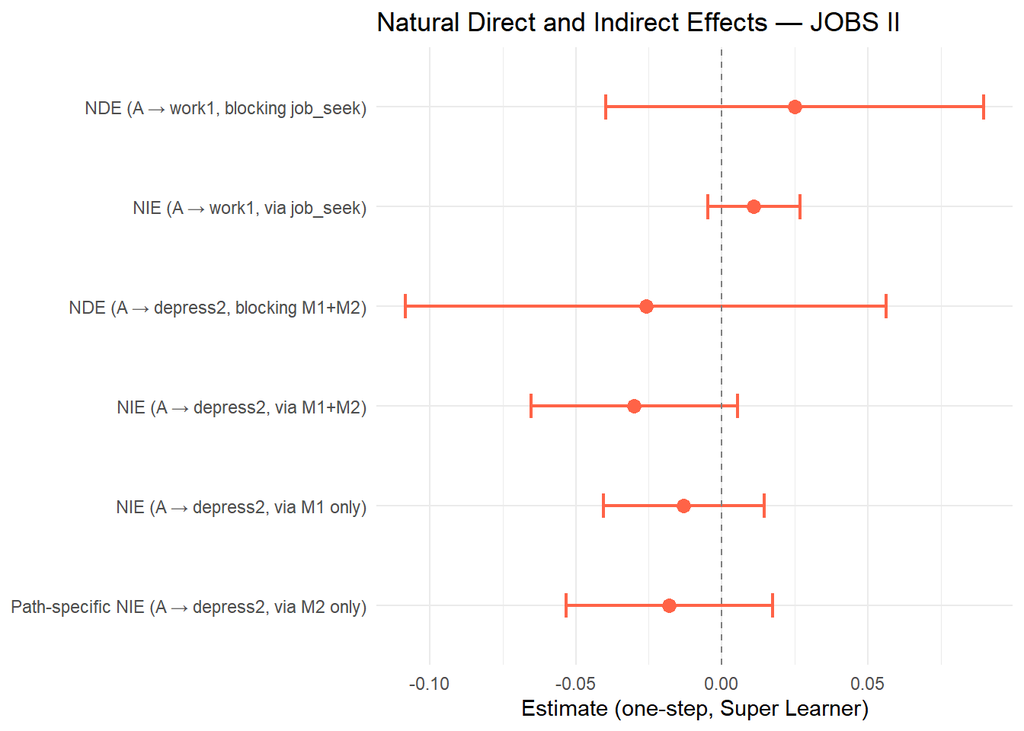

```r
results %>%
  mutate(
    CI_lower = Estimate - 1.96 * SE,
    CI_upper = Estimate + 1.96 * SE,
    Effect   = factor(Effect, levels = rev(Effect))
  ) %>%
  ggplot(aes(x = Estimate, y = Effect)) +
  geom_point(size = 3, color = "tomato") +
  geom_errorbarh(aes(xmin = CI_lower, xmax = CI_upper),
                 height = 0.25, linewidth = 0.8, color = "tomato") +
  geom_vline(xintercept = 0, linetype = "dashed", color = "grey50") +
  theme_minimal() +
  labs(x = "Estimate (one-step, Super Learner)",
       y = NULL,
       title = "Natural Direct and Indirect Effects — JOBS II")
```